# Econometrics - Lecture 2

Simple Linear Regression Basics

Author

Logan Kelly, Ph.D.

Published

January 26, 2025

## 1 Introduction

In this lecture, we delve into the basics of simple linear regression, focusing on the foundational idea that one independent variable $x$ can be used to predict a single dependent variable $y$. We will discuss the model setup (equation of a line), the interpretation of parameters (slope and intercept), and a basic coding example in R to illustrate how to estimate a simple regression model using `lm()`.

## 2 Key Concepts

- Model Setup
- Understanding Parameters
- Reading and Writing R Code

## 3 Theoretical Discussion

### 3.1 Model Setup

- **Equation of a Line**
  The simple linear regression model is expressed as:
  $$y = \beta_0 + \beta_1 x + \varepsilon$$
  where:
  - $y$ is the dependent variable.
  - $x$ is the independent variable.
  - $\beta_0$ is the intercept.
  - $\beta_1$ is the slope coefficient.
  - $\varepsilon$ is the error term.

### 3.2 Understanding Parameters

- **$\beta_0$ (Intercept)**
  - Represents the expected value of $y$ when $x = 0$.
  - Indicates the baseline level of the dependent variable.

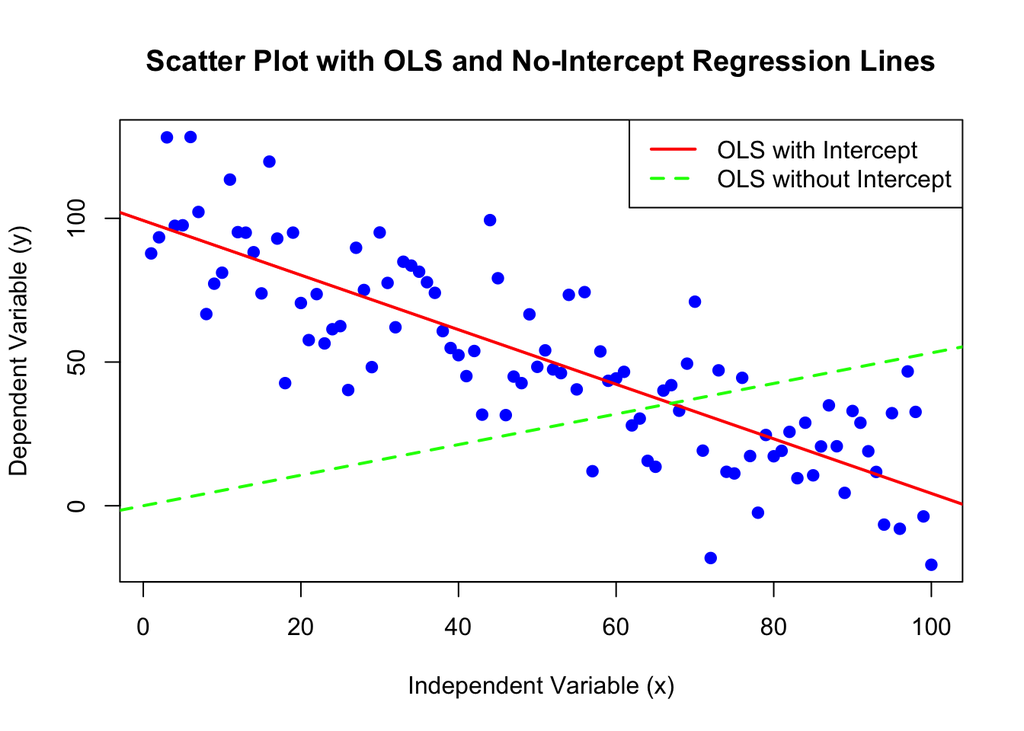

- **$\beta_1$ (Slope)**
  - Measures the expected change in $y$ for a one-unit change in $x$.
  - Indicates the strength and direction of the relationship between $x$ and $y$.
- **$\varepsilon$ (Error Term)**
  - Captures all other factors affecting $y$ that are not included in the model.
  - Assumed to have a mean of zero:
    $$\mathrm{E}(\varepsilon) = 0$$
  - Represents random variability in the dependent variable.

### 3.3 Reading and Writing R Code

- **Estimating a Simple Linear Regression Model in R**  
  The `lm()` function is used to fit linear models. Below is a basic example:

```r
# Example dataset
data(mtcars)

# Fit a simple linear regression model
model <- lm(mpg ~ wt, data = mtcars)

# View the summary of the model
summary(model)
```

```
Call:
lm(formula = mpg ~ wt, data = mtcars)

Residuals:
    Min      1Q  Median      3Q     Max
-4.5432 -2.3647 -0.1252  1.4096  6.8727

Coefficients:
            Estimate Std. Error t value Pr(>|t|)
(Intercept)  37.2851     1.8776  19.858  < 2e-16 ***
wt           -5.3445     0.5591  -9.559 1.29e-10 ***
---
Signif. codes:  0 '***' 0.001 '**' 0.01 '*' 0.05 '.' 0.1 ' ' 1

Residual standard error: 3.046 on 30 degrees of freedom
Multiple R-squared:  0.7528,    Adjusted R-squared:  0.7446
F-statistic: 91.38 on 1 and 30 DF,  p-value: 1.294e-10
```

- **Interpreting the Output**
  - **Coefficients**: Estimates of $\beta_0$ and $\beta_1$.
  - **R-squared**: Proportion of variance in $y$ explained by $x$.
  - **p-values**: Test the null hypothesis that the coefficient is equal to zero.

## 4 Case Study

```r
pacman::p_load_gh("ccolonescu/PoEdata")
pacman::p_load("jtools")
data(food)

# Fit a simple linear regression model
model <- lm(food_exp ~ income, data = food)

# View the summary
summ(model)
```

| Observations | 40 |
| --- | --- |
| Dependent variable | food_exp |
| Type | OLS linear regression |

| F(1,38) | 23.79 |
| --- | --- |
| R² | 0.39 |
| Adj. R² | 0.37 |

|  | Est. | S.E. | t val. | p |
| --- | --- | --- | --- | --- |
| (Intercept) | 83.42 | 43.41 | 1.92 | 0.06 |
| income | 10.21 | 2.09 | 4.88 | 0.00 |

Standard errors: OLS

## 5 Conclusion

- A simple linear regression assumes a direct, linear relationship between one independent variable and the dependent variable.
- OLS estimation finds the best-fitting line by minimizing the sum of squared errors, producing unbiased estimates of slope and intercept under the classic assumptions.
- Practical coding in R typically involves `lm()`, which quickly estimates parameters and provides summary statistics for model evaluation.